# Feature Generation via RDKit

```python
import pandas as pd
import matplotlib as plt
import numpy as np
from pubchempy import Compound, get_compounds
from rdkit import Chem, DataStructs
from rdkit.Chem import Descriptors, Draw
from rdkit.Chem.rdmolops import GetFormalCharge
```

```python
df = pd.read_excel('Perovskite_features.xlsx')
df
```

|  | DOI | Formula | Organic | Space-group | Dimensionality |
| --- | --- | --- | --- | --- | --- |
| 0 | 10.1021/cm9505097 | [N2C8]Pb1I4 | Butylammonium | Pbca | 2D |
| 1 | 10.1021/cm9505097 | [N2C8]Sn1I4 | Butylammonium | Pbca | 2D |
| 2 | 10.1021/cm9505097 | [N2C8]Ge1I4 | Butylammonium | Pnma | 2D |
| 3 | 10.1021/acs.jpcc.9b01550 | [N2H24C8]Pb1Br4 | Butylammonium | Pbca | 2D |
| 4 | 10.1021/acs.chemmater.6b00847 | [C9H48N3]Pb2I7 | Butylammonium | Cmcm (Cccm) | 2D |
| ... | ... | ... | ... | ... | ... |
| 755 | 10.1021/jacs.1c05441 | [O1N1H16C6]Pb1I3 | 3-isopropoxypropylamine | P 21/c | 1 D |
| 756 | 10.1021/jacs.1c05441 | [C32H80N4]Pb1I6 | 2-ethyl-1-hexylamine | P 21/c | 2 D |
| 757 | 10.1021/jacs.1c05441 | [N2H23C9O1]Pb1I6 | diisopropylamine | P 1 | 1 D |
| 758 | 10.1021/jacs.1c05441 | [N4H48C20]Pb1I3 | piperidine | C m c m | 1 D |
| 759 | 10.1021/jacs.1c05441 | [N2H46C17]Pb2I13 | diisopropylethylamine | P n a 21 | 1 D |

760 rows × 5 columns

### Converting compound names to smiles

Using CACTUS (which uses the NCI database) we can find matching smiles for our compound names

```python
from urllib.request import urlopen
from urllib.parse import quote

def to_smiles(name):
    try:
        url = 'http://cactus.nci.nih.gov/chemical/structure/' + quote(name) + '/smiles'
        smiles = urlopen(url).read().decode('utf8')
        return smiles
    except:
        return 'Did not work'
```

```python
df['Smiles'] = [to_smiles(item) for item in df['Organic']]
df['Add charge'] = False
df['Smiles'].value_counts(normalize = True)
```

```
Did not work        0.253947
CCCC[NH3+]          0.078947
[NH3+]CCc1ccccc1    0.039474
[NH3+]Cc1ccccc1     0.031579
NC([NH3+])=N        0.031579
                      ...
[NH4+]              0.001316
CCN1CCNCC1          0.001316
[NH3+]CC(F)(F)F     0.001316
[NH3+]CCC(O)=O      0.001316
CCN(C(C)C)C(C)C     0.001316
Name: Smiles, Length: 168, dtype: float64
```

```python
df
```

|  | DOI | Formula | Organic | Space-group | Dimensionality | Smiles | Add charge |
| --- | --- | --- | --- | --- | --- | --- | --- |
| 0 | 10.1021/cm9505097 | [N2C8]Pb1I4 | Butylammonium | Pbca | 2D | CCCC[NH3+] | False |
| 1 | 10.1021/cm9505097 | [N2C8]Sn1I4 | Butylammonium | Pbca | 2D | CCCC[NH3+] | False |
| 2 | 10.1021/cm9505097 | [N2C8]Ge1I4 | Butylammonium | Pnma | 2D | CCCC[NH3+] | False |
| 3 | 10.1021/acs.jpcc.9b01550 | [N2H24C8]Pb1Br4 | Butylammonium | Pbca | 2D | CCCC[NH3+] | False |
| 4 | 10.1021/acs.chemmater.6b00847 | [C9H48N3]Pb2I7 | Butylammonium | Cmcm (Cccm) | 2D | CCCC[NH3+] | False |
| ... | ... | ... | ... | ... | ... | ... | ... |
| 755 | 10.1021/jacs.1c05441 | [O1N1H16C6]Pb1I3 | 3-isopropoxypropylamine | P 21/c | 1 D | CC(C)OCCCN | False |
| 756 | 10.1021/jacs.1c05441 | [C32H80N4]Pb1I6 | 2-ethyl-1-hexylamine | P 21/c | 2 D | CCCCC(CC)CN | False |
| 757 | 10.1021/jacs.1c05441 | [N2H23C9O1]Pb1I6 | diisopropylamine | P 1 | 1 D | CC(C)NC(C)C | False |
| 758 | 10.1021/jacs.1c05441 | [N4H48C20]Pb1I3 | piperidine | C m c m | 1 D | C1CCNCC1 | False |
| 759 | 10.1021/jacs.1c05441 | [N2H46C17]Pb2I13 | diisopropylethylamine | P n a 21 | 1 D | CCN(C(C)C)C(C)C | False |

760 rows × 7 columns

This function will serve to assess the percent of names successfully converted to smiles

```python
def percent_converted(smiles):
    not_converted = 0
    total = 0
    for item in smiles:
        if item == 'Did not work':
            not_converted += 1
            total += 1
        else:
            total += 1
    converted = (1-(not_converted/total))*100
    return converted
```

As we see, the initial conversion is not ideal. Upon observation, some trends can be noted that lead to compound names not successfully converting. These include cations (CACTUS has many more neutral compounds than charged species), as well as simple nomenclature changes.

```python
print(percent_converted(df['Smiles']))
```

```
74.60526315789473
```

```python
for x in range(0, 760):
    compound = str(df.loc[x]['Organic'])
    smiles = str(df.loc[x]['Smiles'])
    if smiles == 'Did not work':
        print('Unchanged: ', compound)
        compound = compound.replace('-O-', '-2-')
        compound = compound.replace('-o-', '-2-')
        compound = compound.replace(' deprotonated', '')
        if 'ammonium' in compound:
            compound = compound.replace('ammonium', 'amine')
            add_charge = True
        elif 'protonated' in compound:
            compound = compound.replace('protonated', '')
            add_charge = True
        if 'aminee' in compound:
            compound = compound.replace('aminee', 'aminoe')
        print('Changed: ', compound)
        deprotonated_smile = to_smiles(compound)
        print(deprotonated_smile, 'Charge to add: ', add_charge)
        df.loc[x, 'Smiles'] = deprotonated_smile
        df.loc[x, 'Add charge'] = add_charge
        #added_charge.append(charge_to_add)
```

```
Unchanged:  1,6-hexanediammonium
Changed:  1,6-hexanediamine
NCCCCCCN Charge to add:  True
Unchanged:  1,6-hexanediammonium
Changed:  1,6-hexanediamine
NCCCCCCN Charge to add:  True
Unchanged:  1,6-hexanediammonium
Changed:  1,6-hexanediamine
NCCCCCCN Charge to add:  True
Unchanged:  1,8-octanediammonium
Changed:  1,8-octanediamine
NCCCCCCCCN Charge to add:  True
Unchanged:  1,12-dodecanediammonium
Changed:  1,12-dodecanediamine
NCCCCCCCCCCCCN Charge to add:  True
Unchanged:  1,7-heptanediammonium
Changed:  1,7-heptanediamine
NCCCCCCCN Charge to add:  True
Unchanged:  1,8-octanediammonium
Changed:  1,8-octanediamine
NCCCCCCCCN Charge to add:  True
Unchanged:  1,10-decanediammonium
Changed:  1,10-decanediamine
NCCCCCCCCCCN Charge to add:  True
Unchanged:  1,12-dodecanediammonium
Changed:  1,12-dodecanediamine
NCCCCCCCCCCCCN Charge to add:  True
Unchanged:  1,2-ethanediammonium
Changed:  1,2-ethanediamine
NCCN Charge to add:  True
Unchanged:  Diphenylmethane - 4,4'-diammonium
Changed:  Diphenylmethane - 4,4'-diamine
Did not work Charge to add:  True
Unchanged:  1,8-octanediammonium
Changed:  1,8-octanediamine
NCCCCCCCCN Charge to add:  True
Unchanged:  1,8-octanediammonium
Changed:  1,8-octanediamine
NCCCCCCCCN Charge to add:  True
Unchanged:  1,8-octanediammonium
```

[output cut: 524 more lines]

```
Unchanged:  3-pyren-1-yloxypropan-1-ammonium
Changed:  3-pyren-1-yloxypropan-1-amine
NCCCOc1ccc2ccc3cccc4ccc1c2c34 Charge to add:  True
Unchanged:  4-pyren-1-yloxybutan-1-ammonium
Changed:  4-pyren-1-yloxybutan-1-amine
NCCCCOc1ccc2ccc3cccc4ccc1c2c34 Charge to add:  True
Unchanged:  2-perylen-1-yloxyethanammonium
Changed:  2-perylen-1-yloxyethanamine
NCCOc1ccc2cccc3c4cccc5cccc(c45)c1c23 Charge to add:  True
Unchanged:  2-(5-thiophen-2-ylthiophen-2-yl)sulfanylethanammonium
Changed:  2-(5-thiophen-2-ylthiophen-2-yl)sulfanylethanamine
NCCSc1sc(cc1)c2sccc2 Charge to add:  True
Unchanged:  2-[5-[5-(2-ammoniumethylsulfanyl)thiophen-2-yl]thiophen-2-yl]sulfanylethanammonium
Changed:  2-[5-[5-(2-aminoethylsulfanyl)thiophen-2-yl]thiophen-2-yl]sulfanylethanamine
NCCSc1sc(cc1)c2sc(SCCN)cc2 Charge to add:  True
```

By applying our changes to the compounds that did not convert, we have increased the conversion from ~75% to ~92%

```python
print(percent_converted(df['Smiles']))
```

```
91.71052631578948
```

```python
df.replace('Did not work', np.nan, inplace = True)
```

We can now remove the remaining non-converted compounds and save them in a seperate file to assess manually.

```python
test_df = df[df['Smiles'].isna()]
test_df.to_csv('nonconverted_systems.csv')
```

```python
df.dropna(inplace = True)
df
```

|  | DOI | Formula | Organic | Space-group | Dimensionality | Smiles | Add charge |
| --- | --- | --- | --- | --- | --- | --- | --- |
| 0 | 10.1021/cm9505097 | [N2C8]Pb1I4 | Butylammonium | Pbca | 2D | CCCC[NH3+] | False |
| 1 | 10.1021/cm9505097 | [N2C8]Sn1I4 | Butylammonium | Pbca | 2D | CCCC[NH3+] | False |
| 2 | 10.1021/cm9505097 | [N2C8]Ge1I4 | Butylammonium | Pnma | 2D | CCCC[NH3+] | False |
| 3 | 10.1021/acs.jpcc.9b01550 | [N2H24C8]Pb1Br4 | Butylammonium | Pbca | 2D | CCCC[NH3+] | False |
| 4 | 10.1021/acs.chemmater.6b00847 | [C9H48N3]Pb2I7 | Butylammonium | Cmcm (Cccm) | 2D | CCCC[NH3+] | False |
| ... | ... | ... | ... | ... | ... | ... | ... |
| 755 | 10.1021/jacs.1c05441 | [O1N1H16C6]Pb1I3 | 3-isopropoxypropylamine | P 21/c | 1 D | CC(C)OCCCN | False |
| 756 | 10.1021/jacs.1c05441 | [C32H80N4]Pb1I6 | 2-ethyl-1-hexylamine | P 21/c | 2 D | CCCCC(CC)CN | False |
| 757 | 10.1021/jacs.1c05441 | [N2H23C9O1]Pb1I6 | diisopropylamine | P 1 | 1 D | CC(C)NC(C)C | False |
| 758 | 10.1021/jacs.1c05441 | [N4H48C20]Pb1I3 | piperidine | C m c m | 1 D | C1CCNCC1 | False |
| 759 | 10.1021/jacs.1c05441 | [N2H46C17]Pb2I13 | diisopropylethylamine | P n a 21 | 1 D | CCN(C(C)C)C(C)C | False |

692 rows × 7 columns

We need to re-protonate compounds that we manually deprotonated for the sake of converting to smiles. The below function accomplishes this.

```python
def protonate_amine(mol, protonate):
    if protonate == True:
        Nitrogen_index = mol.GetSubstructMatch(Chem.MolFromSmarts('N'))
        mol.GetAtomWithIdx(*Nitrogen_index).SetFormalCharge(1)
    return mol
```

## Generating 2D features

```python
molecules = [Chem.MolFromSmiles(item) for item in df['Smiles']]
add_charge = df['Add charge'].tolist()

#Create a dictionary containing molecule: charge_add pairs
charges = {molecules[i]: add_charge[i] for i in range(len(add_charge))}

protonated_molecules = [protonate_amine(molecule, charges[molecule]) for molecule in molecules]

#Generate 2D features for each compound
df['Mol. Wt.'] = [Descriptors.MolWt(i) for i in protonated_molecules]
df['H-bond Donors'] = [Descriptors.NumHDonors(i) for i in protonated_molecules]
df['PSA'] = [Descriptors.TPSA(i) for i in protonated_molecules]
df['ASA'] = [Descriptors.LabuteASA(i) for i in protonated_molecules]
df['MolLogP'] = [Descriptors.MolLogP(i) for i in protonated_molecules]
df['Rotatable Bonds'] = [Descriptors.NumRotatableBonds(i) for i in protonated_molecules]
```

## Visualizing molecules

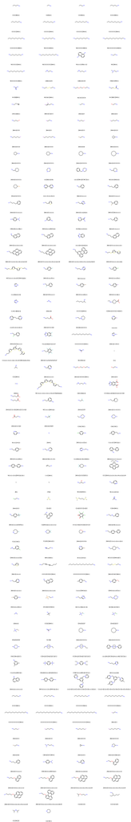

```python
def get_unique_mols(mols):
    unique_molecules = []
    unique_molecules_mw = []
    for item in mols:
        item_mw = Descriptors.MolWt(item)
        if item_mw not in unique_molecules_mw:
            unique_molecules.append(item)
            unique_molecules_mw.append(item_mw)
    return unique_molecules

uniques = get_unique_mols(protonated_molecules)
unique_smiles = [Chem.MolToSmiles(mol) for mol in uniques]
Draw.MolsToGridImage(uniques, legends=unique_smiles,  molsPerRow=4,subImgSize=(400,200), maxMols = len(uniques))
```

## Checking a new compound in the dataset

The functions below allow for searching the database to see if a structure is present. Alternatively, if the compound is not persent, the most structurally similiar structure is returned.

```python
def find_nearest_match(smiles, greatest_similarity = 0, nearest_match = 'None'):
    search_mol = Chem.MolFromSmiles(smiles)
    search_fingerprint = Chem.RDKFingerprint(search_mol)
    for item in df['Smiles']:
        item_as_mol = Chem.MolFromSmiles(item)
        item_as_fingerprint = Chem.RDKFingerprint(item_as_mol)
        similarity = DataStructs.FingerprintSimilarity(search_fingerprint,item_as_fingerprint)
        if similarity > greatest_similarity:
            greatest_similarity = round(similarity, 3)
            nearest_match = item
    if similarity == 1:
        return_phrase = "This molecule is present in the dataset"
    else:
        return_phrase = "The nearest match is " + str(nearest_match) + " with a Tanimoto similarity of " + str(greatest_similarity)
    print(return_phrase)

def nearest_match(smiles, greatest_similarity = 0, nearest_match = 'None'):
    search_mol = Chem.MolFromSmiles(smiles)
    search_fingerprint = Chem.RDKFingerprint(search_mol)
    for item in df['Smiles']:
        item_as_mol = Chem.MolFromSmiles(item)
        item_as_fingerprint = Chem.RDKFingerprint(item_as_mol)
        similarity = DataStructs.FingerprintSimilarity(search_fingerprint,item_as_fingerprint)
        if similarity > greatest_similarity:
            greatest_similarity = round(similarity, 3)
            nearest_match = item
    return (str(nearest_match), str(greatest_similarity))

def match_printout(smiles):
    nearest_smiles = (nearest_match(smiles)[0])
    near_match = (nearest_match(smiles)[1])
    molecule1 = Chem.MolFromSmiles(smiles)
    molecule2 = Chem.MolFromSmiles(nearest_smiles)
    if near_match == '1.0':
        legend_phrase = str('Exact match. ' + smiles + ' is currently present in the dataset.')
        print(legend_phrase)
        return Draw.MolToImage(molecule1)
    else:
        legend_phrase = str('The nearest match to ' + smiles + ' (left) in the dataset is ' + nearest_smiles + ' (right).\nSimilarity index: ' + near_match)
        print(legend_phrase)
        return Draw.MolsToGridImage((molecule1, molecule2), molsPerRow=2,subImgSize=(200,200))
```

```python
pyridine_smiles = to_smiles('pyridine')
find_nearest_match(pyridine_smiles)
```

```
The nearest match is Brc1ccc[nH+]c1 with a Tanimoto similarity of 0.449
```

```
The nearest match to c1ccncc1 (left) in the dataset is Brc1ccc[nH+]c1 (right).
Similarity index: 0.449
```

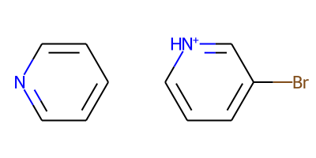

```python
match_printout(pyridine_smiles)
```

```
Exact match. CC(C)NC(C)C is currently present in the dataset.
```

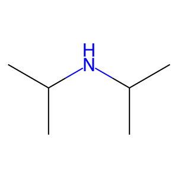

```python
diisopropylamine_smiles = to_smiles('diisopropylamine')
match_printout(diisopropylamine_smiles)
```

# 3D Visualization (demonstrated on rdkit.blogspot)

```python
import py3Dmol
def drawmodel(mol,p=None,confId=-1):
        molblock = Chem.MolToMolBlock(mol,confId=confId)
        if p is None:
            p = py3Dmol.view(width=400,height=400)
        p.removeAllModels()
        p.addModel(molblock,'sdf')
        p.setStyle({'stick':{}})
        p.setBackgroundColor('white')
        p.zoomTo()
        return p.show()
```

```python
drawmodel(protonated_molecules[35])
```